# Predição Valor Imóvel

Marcio Cruz

29/06/2021

## Case

De acordo com a localização de um imóvel, sabe-se que o valor do mesmo pode variar substancialmente. Na base de dados disponibilizada são fornecidas informações sobre o valor do imóvel (R$) por mil m², a distância para estação de metrô (km), a quantidade de comércios próximos e a idade (em anos) do imóvel, em um bairro bem localizado de grande centro urbano. Quais são as características relacionadas ao imóvel que predizem seu valor?

## Respostas

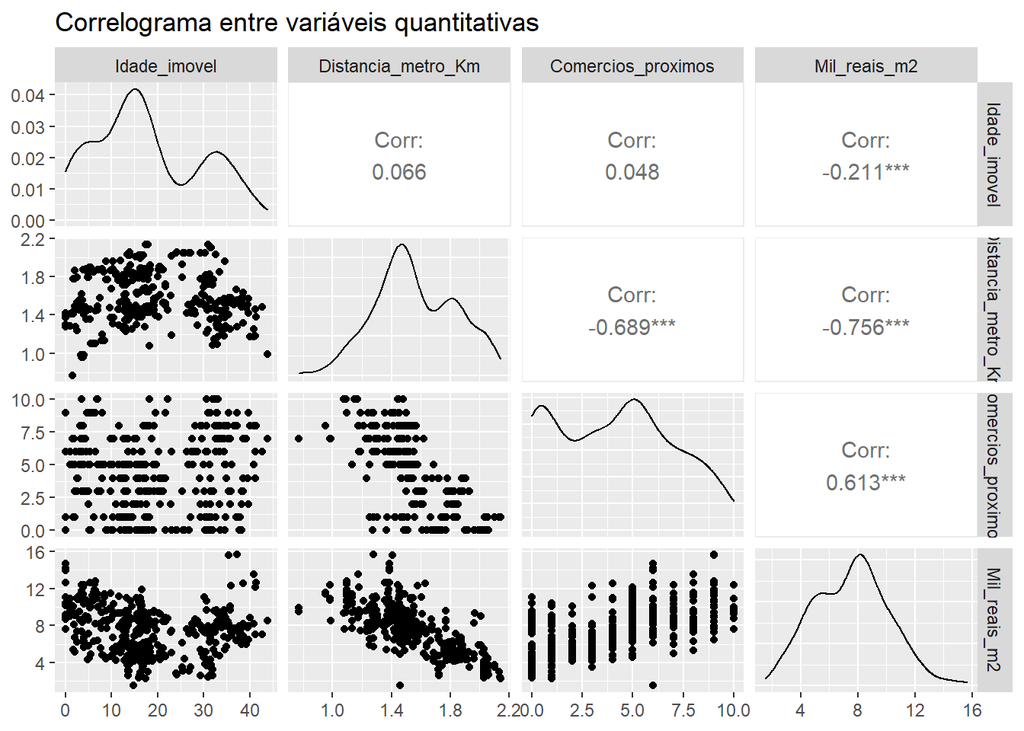

### c) Obtenha o modelo de regressão linear múltipla, considerando um nível de significância de 5% para seleção de variáveis.

```r
regressao.1 <- lm(data=imobiliario, imobiliario$Mil_reais_m2 ~ imobiliario$Idade_imovel + imobiliario$Distancia_metro_Km + imobiliario$Comercios_proximos)
summary(regressao.1)
```

```
##
## Call:
## lm(formula = imobiliario$Mil_reais_m2 ~ imobiliario$Idade_imovel +
##     imobiliario$Distancia_metro_Km + imobiliario$Comercios_proximos,
##     data = imobiliario)
##
## Residuals:
##     Min      1Q  Median      3Q     Max
## -7.0945 -0.9980 -0.1722  0.7861  6.9936
##
## Coefficients:
##                                 Estimate Std. Error t value
## (Intercept)                    16.493840   0.744620  22.151
## imobiliario$Idade_imovel       -0.041448   0.007054  -5.876
## imobiliario$Distancia_metro_Km -5.739872   0.405438 -14.157
## imobiliario$Comercios_proximos  0.183508   0.037588   4.882
##                                            Pr(>|t|)
## (Intercept)                    < 0.0000000000000002 ***
## imobiliario$Idade_imovel              0.00000000872 ***
## imobiliario$Distancia_metro_Km < 0.0000000000000002 ***
## imobiliario$Comercios_proximos        0.00000150748 ***
## ---
## Signif. codes:  0 '***' 0.001 '**' 0.01 '*' 0.05 '.' 0.1 ' ' 1
##
## Residual standard error: 1.615 on 409 degrees of freedom
## Multiple R-squared:  0.6197, Adjusted R-squared:  0.6169
## F-statistic: 222.1 on 3 and 409 DF,  p-value: < 0.00000000000000022
```

### d) Interprete os parâmetros do modelo e o coeficiente de determinação.

#### -0.041448 é a redução do preço do m2 para cada unidade de aumento da idade de imóvel, mantendo as outras variáveis zeradas.

#### 5.739872 é a redução do preço do m2 para cada unidade de aumento da distância ao metrô, mantendo as outras variáveis zeradas.

#### 0.183508 é o aumento do preço do m2 para cada unidade de aumento da quantidade de comércios próximos, manteno as outras variáveis zeradas.

#### 61,69% do preço do m2 é explicado pelas variáveis Idade do Imóvel, distância deste ao metrô e quantidade de comércios próximos.

### e) Apresente a equação do modelo estimado.

y_estimado <- 16.493840 + (-0.04144 * idade) + (-5.739872 * distanciametro) + (0.183508 * qtdecomercios)

```r
idade <- 5
distanciametro <- 1
qtdecomercios <- 0
y_estimado <- (16.493840 + (-0.04144 * idade) + (-5.739872*distanciametro) + (0.183508*qtdecomercios))
valor_estimado <- 85 * y_estimado * 1000
```